# Analysis of Property Prices East and West of Alter Rd, Detroit MI

Emmett Henry

2026-05-28

### Data and libraries

The parcels dataset used in this analysis was generated using 30 random parcels selected from each side of a 1 km buffer around Fox Creek in QGIS. Original parcel boundary data was acquired from Wayne County GIS data’s Parcels dataset at https://www.waynecountymi.gov/Government/Departments/Information-Technology/Maps-Data/GIS-Data. Home prices were then determined by searching Zillow and recording the current Zillow price as of 5/12/2026. The original dataset was created in Google Sheets, then exported as a CSV file for analysis.

The readr library is used to convert the currency formatting of Google Sheets into standard numeric format.

```r
parcels <- read.csv("Jefferson_Chalmers_Home_Prices.csv")

library(readr)
```

Example data rows are shown below. The first four columns identify the parcel in question by street, city, state, and zip code. `Zillow.Price` is the recorded Zillow price as of 5/12/2026. `(Not on Zillow)` refers to a property that had no information on Zillow or could not be located in Zillow’s records. `“Unknown”` or `“Price Unknown”` are quotes directly from Zillow. `Price.Date` is the date that the Zillow data was accessed. `Zillow.Property.Type` is the property type listed on Zillow, with `(Not on Zillow)` used as a placeholder for properties that could not be found on the site. `E.W.of.Alter.Rd` refers to a property’s position either East of West of Alter Rd along Fox Creek. `Notes.` refers to any additional insight on the property that could be gained through images on Zillow, then through Google Maps imagery and street view if no Zillow image was present. Notes are not official data and represent the author’s best guess as to the property’s function, and thus have not been included in this analysis.

```r
head(parcels)
```

```
##            propstreet propcity propstate propzip    Zillow.Price Price.Date
## 1 14640 HARBOR ISLAND  DETROIT        MI   48215 (Not on Zillow)  5/12/2026
## 2         276 ASHLAND  DETROIT        MI   48215 (Not on Zillow)  5/12/2026
## 3      937 MANISTIQUE  DETROIT        MI   48215 (Not on Zillow)  5/12/2026
## 4      870 MANISTIQUE  DETROIT        MI   48215       "Unknown"  5/12/2026
## 5          334 PHILIP  DETROIT        MI   48215 "Price Unknown"  5/12/2026
## 6         878 ASHLAND  DETROIT        MI   48215     $262,500.00  5/12/2026
##   Zillow.Property.Type E.W.of.Alter.Rd
## 1      (Not on Zillow)            West
## 2      (Not on Zillow)            West
## 3      (Not on Zillow)            West
## 4              Unknown            West
## 5              Unknown            West
## 6        Single Family            West
##                                               Notes.
## 1 Could not identify via both Zillow and Google Maps
## 2                                        Boat House?
## 3                "Original Primitive Baptist Church"
## 4                                        Vacant Lot?
## 5                                         Vacant Lot
## 6
```

### Data Cleaning

A new column `Zillow.Numeric` is created with converted numeric price data stripped of dollar signs and commas. Non-numeric values are changed to `NA`. This allows for easy analysis of home prices.

```r
parcels$Zillow.Numeric <- parse_number(parcels$Zillow.Price)
```

The first few rows of the dataset with the new column are shown below:

```r
head(parcels)
```

```
##            propstreet propcity propstate propzip    Zillow.Price Price.Date
## 1 14640 HARBOR ISLAND  DETROIT        MI   48215 (Not on Zillow)  5/12/2026
## 2         276 ASHLAND  DETROIT        MI   48215 (Not on Zillow)  5/12/2026
## 3      937 MANISTIQUE  DETROIT        MI   48215 (Not on Zillow)  5/12/2026
## 4      870 MANISTIQUE  DETROIT        MI   48215       "Unknown"  5/12/2026
## 5          334 PHILIP  DETROIT        MI   48215 "Price Unknown"  5/12/2026
## 6         878 ASHLAND  DETROIT        MI   48215     $262,500.00  5/12/2026
##   Zillow.Property.Type E.W.of.Alter.Rd
## 1      (Not on Zillow)            West
## 2      (Not on Zillow)            West
## 3      (Not on Zillow)            West
## 4              Unknown            West
## 5              Unknown            West
## 6        Single Family            West
##                                               Notes. Zillow.Numeric
## 1 Could not identify via both Zillow and Google Maps             NA
## 2                                        Boat House?             NA
## 3                "Original Primitive Baptist Church"             NA
## 4                                        Vacant Lot?             NA
## 5                                         Vacant Lot             NA
## 6                                                            262500
```

### Welch’s Two-Sample T-test:

A common tool for comparing means of two groups is the T-Test. R defaults to Welch’s T-Test for two-sample t-tests, which allows for smaller sample sizes. Before we can use this test, we must check that its assumptions are met, including independence of observatios, a continuous dependent variable, and normal distribution of the populations to be analyzed.

Independence of Observations: True, populations were chosen by a random selection operation in QGIS.

Continuous Dependent Variable: True, variable is in dollars.

Normality: validate using the Shapiro-Wilk Normality test for each population. The first population is parcels East of Alter Rd, which is extracted by a subset operation, and the other population is parcels West of Alter Rd, which is again extracted using a subset operation. shapiro.test is then applied to the Zillow.Numeric values of each of the these subsets.

```r
east_parcels <- subset(parcels, parcels$E.W.of.Alter.Rd == "East")

west_parcels <- subset(parcels, parcels$E.W.of.Alter.Rd == "West")

shapiro.test(east_parcels$Zillow.Numeric)
```

```
##
##  Shapiro-Wilk normality test
##
## data:  east_parcels$Zillow.Numeric
## W = 0.98594, p-value = 0.9567
```

```r
shapiro.test(west_parcels$Zillow.Numeric)
```

```
##
##  Shapiro-Wilk normality test
##
## data:  west_parcels$Zillow.Numeric
## W = 0.64354, p-value = 1.383e-06
```

To understand why the West parcels failed this assumption, histograms showing the east and west parcels’ price distributions are shown below. The East histogram shows a fairly standard bell shape, while the West histogram has a strong right skew.

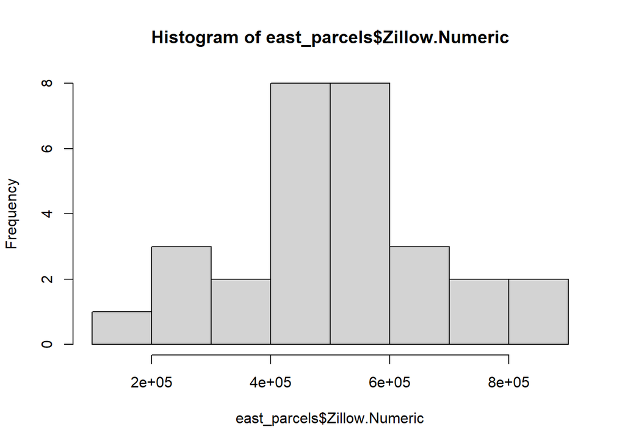

```r
hist(east_parcels$Zillow.Numeric)
```

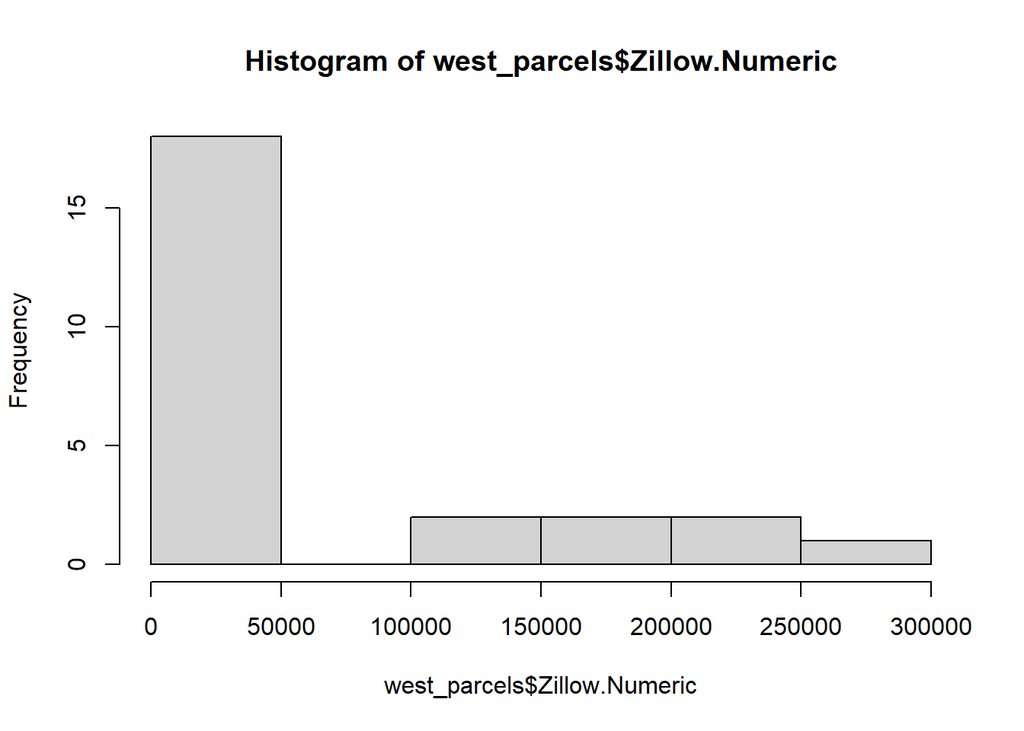

```r
hist(west_parcels$Zillow.Numeric)
```

One potential fix for right-skewed data is to take the log of the dataset. A histogram of the log of West parcel prices is shown below. Although it is less right-skewed than before, it still does not show an ideal bell-curve shape.

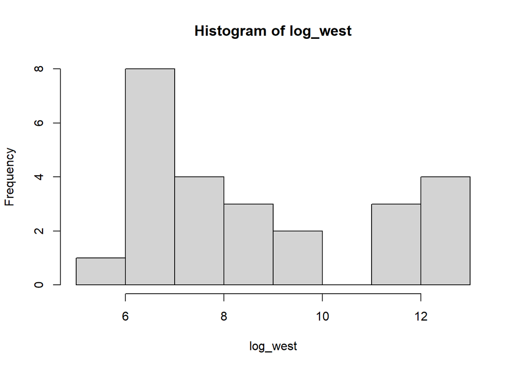

```r
log_west <- log(west_parcels$Zillow.Numeric)

hist(log_west)
```

To confirm whether this logged data would meet the t-test requirement, a Shapiro-Wilk normality test is applied to it. As we can see below, the resulting p-value of 0.0006687 still falls below the standard alpha value of 0.05, leading us to once again reject the null hypothesis that the data is normally distributed. Thus, taking the log of the parcel price data does not fix the non-normality issue, and it still **fails** the Shapiro-Wilk test for normality.

```r
shapiro.test(log_west)
```

```
##
##  Shapiro-Wilk normality test
##
## data:  log_west
## W = 0.82715, p-value = 0.0006687
```

### Non-Parametric Test: Mann-Whitney-Wilcoxon Test

The Mann-Whitney-Wilcoxon Test is an alternative to the T-Test that accounts for non-normal distributions of populations, thus resolving the issue of non-normality in the West parcel price data. Results comparing East and West parcel price data are seen below.

```r
wilcox.test(Zillow.Numeric ~ E.W.of.Alter.Rd, data = parcels)
```

```
##
##  Wilcoxon rank sum test with continuity correction
##
## data:  Zillow.Numeric by E.W.of.Alter.Rd
## W = 719, p-value = 6.516e-10
## alternative hypothesis: true location shift is not equal to 0
```

Given the resulting p-value of 6.516e-10, we reject the null hypothesis that the true difference in means is equal to 0. Thus, we can conclude there is a significant difference between the Zillow home prices for the East and West side of Alter Rd. However, this test does not provide estimated means for either group, or show the estimated difference between the two.

### T-Test Example

Although the assumptions for this test are not fully met, a T-Test gives estimated means for the different populations. While we cannot be completely confident in these results due to the non-normality in the West data, a T-Test for the East and West parcel data is presented below.

```r
t.test(Zillow.Numeric ~ E.W.of.Alter.Rd, data = parcels)
```

```
##
##  Welch Two Sample t-test
##
## data:  Zillow.Numeric by E.W.of.Alter.Rd
## t = 12.409, df = 43.361, p-value = 7.311e-16
## alternative hypothesis: true difference in means between group East and group West is not equal to 0
## 95 percent confidence interval:
##  379608.2 526901.5
## sample estimates:
## mean in group East mean in group West
##          507241.38           53986.56
```

The resulting p-value of 7.311e-16 falls below the 0.05 alpha value, concurring with the Mann-Whitney-Wilcoxon test results. The mean of East parcels given is $507,241.38, and is roughly ten times larger than the West parcels’ mean of $53,986.56. Thus, while this test is not entirely reliable, there is a large difference between estimated means, and we can likely assume the East parcels have a much higher average value than the west parcels.

### Conclusion and Discussion

Given the results of the Mann-Whitney-Wilcoxon non-parametric test, we conclude that there is a significant difference between parcel prices on the East and West sides of Alter Rd in Detroit, MI. A preliminary T-Test, while not necessarily reliable, suggests that the East parcel prices are, on average, roughly 10 times greater than West parcel prices.

Further investigation could be useful in multiple areas. For one, several parcels were omitted from this analysis due to lacking information on Zillow. A more comprehensive dataset might yield additional insights. Furthermore, an analysis of property types could highlight reasons for the differences seen in this analysis. A brief skim of the dataset itself shows relatively homogenous parcel types for the East side, but hgihly mixed parcel uses for the West side. Finally, the Alter Rd boundary nearly coincides with the border between the cities of Detroit and Grosse Point Woods. Determining to what extend these differences in property prices are caused by the canal versus the city boundary would be an ideal next step for research.